# **0. Introduction**

Video games are a medium that has taken the world by storm over the few decades they have existed. From a niche industry in the early 1980s to one that generates on the order of $100B annually, the growth has provided a brand new segment of economy to look at.

```python
# Importing libraries
import sqlite3
import pandas as pd
import numpy as np
import matplotlib.pyplot as plt
import scipy.stats as scs
from sklearn import model_selection
from sklearn import linear_model
from sklearn import preprocessing
import seaborn as sb
import warnings
warnings.filterwarnings('ignore')
```

# **1. Data Collection**

In order to do any analysis of data, we need data. For the purposes of this tutorial, data was retrieved from a [Kaggle](https://www.kaggle.com/) repository that can be found [here](https://www.kaggle.com/datasets/nikdavis/steam-store-games). This repository consists of six documents, of which this tutorial will be discussing two. These data are pulled from the APIs of both [Steam](https://store.steampowered.com/) and [SteamSpy](https://steamspy.com/) circa 2019.

## **1a. Games**

```python
games = pd.read_csv('/content/drive/MyDrive/Colab Notebooks/steam.csv')
games.head()
```

|  | appid | name | release_date | english | developer | publisher | platforms | required_age | categories | genres | steamspy_tags | achievements | positive_ratings | negative_ratings | average_playtime | median_playtime | owners | price |
| --- | --- | --- | --- | --- | --- | --- | --- | --- | --- | --- | --- | --- | --- | --- | --- | --- | --- | --- |
| 0 | 10 | Counter-Strike | 2000-11-01 | 1 | Valve | Valve | windows;mac;linux | 0 | Multi-player;Online Multi-Player;Local Multi-P... | Action | Action;FPS;Multiplayer | 0 | 124534 | 3339 | 17612 | 317 | 10000000-20000000 | 7.19 |
| 1 | 20 | Team Fortress Classic | 1999-04-01 | 1 | Valve | Valve | windows;mac;linux | 0 | Multi-player;Online Multi-Player;Local Multi-P... | Action | Action;FPS;Multiplayer | 0 | 3318 | 633 | 277 | 62 | 5000000-10000000 | 3.99 |
| 2 | 30 | Day of Defeat | 2003-05-01 | 1 | Valve | Valve | windows;mac;linux | 0 | Multi-player;Valve Anti-Cheat enabled | Action | FPS;World War II;Multiplayer | 0 | 3416 | 398 | 187 | 34 | 5000000-10000000 | 3.99 |
| 3 | 40 | Deathmatch Classic | 2001-06-01 | 1 | Valve | Valve | windows;mac;linux | 0 | Multi-player;Online Multi-Player;Local Multi-P... | Action | Action;FPS;Multiplayer | 0 | 1273 | 267 | 258 | 184 | 5000000-10000000 | 3.99 |
| 4 | 50 | Half-Life: Opposing Force | 1999-11-01 | 1 | Gearbox Software | Valve | windows;mac;linux | 0 | Single-player;Multi-player;Valve Anti-Cheat en... | Action | FPS;Action;Sci-fi | 0 | 5250 | 288 | 624 | 415 | 5000000-10000000 | 3.99 |

Let's make sure our data doesn't have any duplicates. This is rather easy to do: we want one row for every game ID.

```python
# Check the length of our entire data set against the number of unique App IDs
print(len(games['appid']))
print(len(games['appid'].unique()))
```

```
27075
27075
```

Looking at the `games` table, we have 18 columns. These columns are described below.

[output not shown]

## **1b. Tags**

```python
tags = pd.read_csv('/content/drive/MyDrive/Colab Notebooks/steamspy_tag_data.csv')
tags.head()
```

|  | appid | 1980s | 1990s | 2.5d | 2d | 2d_fighter | 360_video | 3d | 3d_platformer | 3d_vision | ... | warhammer_40k | web_publishing | werewolves | western | word_game | world_war_i | world_war_ii | wrestling | zombies | e_sports |
| --- | --- | --- | --- | --- | --- | --- | --- | --- | --- | --- | --- | --- | --- | --- | --- | --- | --- | --- | --- | --- | --- |
| 0 | 10 | 144 | 564 | 0 | 0 | 0 | 0 | 0 | 0 | 0 | ... | 0 | 0 | 0 | 0 | 0 | 0 | 0 | 0 | 0 | 550 |
| 1 | 20 | 0 | 71 | 0 | 0 | 0 | 0 | 0 | 0 | 0 | ... | 0 | 0 | 0 | 0 | 0 | 0 | 0 | 0 | 0 | 0 |
| 2 | 30 | 0 | 0 | 0 | 0 | 0 | 0 | 0 | 0 | 0 | ... | 0 | 0 | 0 | 0 | 0 | 5 | 122 | 0 | 0 | 0 |
| 3 | 40 | 0 | 0 | 0 | 0 | 0 | 0 | 0 | 0 | 0 | ... | 0 | 0 | 0 | 0 | 0 | 0 | 0 | 0 | 0 | 0 |
| 4 | 50 | 0 | 77 | 0 | 0 | 0 | 0 | 0 | 0 | 0 | ... | 0 | 0 | 0 | 0 | 0 | 0 | 0 | 0 | 0 | 0 |

5 rows × 372 columns

The `tags` table is an encoding of user votes for each tag in each game. This is an expansion of the lists found in the `steamspy_tags` column of the `games` table. There are 371 unique tags.

# **2. Data Management**

## **2a. Auxiliary Tables**

Now that we have our data, we want it to be in a format that is easy for our code to analyze. As text isn't particularly easy to do calculations on, we can convert some of our text fields into numerical data. To do this, we will one-hot encode a few of our columns of string lists into separate tables of binary information. The `tags` table already follows this format and has a workable form of the `steamspy_tags` column, so we will let that column alone and work on the other three dimensions we want to use: `genres`, `categories`, and `platforms`.

```python
# Convert the semicolon-separated string to a list,
# and use that to find a list of all unique genres
games['genres_list'] = games['genres'].str.split(';')
genres_set = sorted(set(sum(games['genres_list'].tolist(),[])))

# Create a new table with a column for each genre...
genres = games[['appid']]
for g in genres_set:
  genres[g] = games['genres'].apply(lambda x: 1 if g in x else 0)

genres.head()
```

|  | appid | Accounting | Action | Adventure | Animation & Modeling | Audio Production | Casual | Design & Illustration | Documentary | Early Access | ... | Sexual Content | Simulation | Software Training | Sports | Strategy | Tutorial | Utilities | Video Production | Violent | Web Publishing |
| --- | --- | --- | --- | --- | --- | --- | --- | --- | --- | --- | --- | --- | --- | --- | --- | --- | --- | --- | --- | --- | --- |
| 0 | 10 | 0 | 1 | 0 | 0 | 0 | 0 | 0 | 0 | 0 | ... | 0 | 0 | 0 | 0 | 0 | 0 | 0 | 0 | 0 | 0 |
| 1 | 20 | 0 | 1 | 0 | 0 | 0 | 0 | 0 | 0 | 0 | ... | 0 | 0 | 0 | 0 | 0 | 0 | 0 | 0 | 0 | 0 |
| 2 | 30 | 0 | 1 | 0 | 0 | 0 | 0 | 0 | 0 | 0 | ... | 0 | 0 | 0 | 0 | 0 | 0 | 0 | 0 | 0 | 0 |
| 3 | 40 | 0 | 1 | 0 | 0 | 0 | 0 | 0 | 0 | 0 | ... | 0 | 0 | 0 | 0 | 0 | 0 | 0 | 0 | 0 | 0 |
| 4 | 50 | 0 | 1 | 0 | 0 | 0 | 0 | 0 | 0 | 0 | ... | 0 | 0 | 0 | 0 | 0 | 0 | 0 | 0 | 0 | 0 |

5 rows × 30 columns

```python
# ...repeat the process for categories...
games['categories_list'] = games['categories'].str.split(';')
categories_set = sorted(set(sum(games['categories_list'].tolist(),[])))

categories = games[['appid']]
for c in categories_set:
  categories[c] = games['categories'].apply(lambda x: 1 if c in x else 0)

categories.head()
```

|  | appid | Captions available | Co-op | Commentary available | Cross-Platform Multiplayer | Full controller support | In-App Purchases | Includes Source SDK | Includes level editor | Local Co-op | ... | Stats | Steam Achievements | Steam Cloud | Steam Leaderboards | Steam Trading Cards | Steam Turn Notifications | Steam Workshop | SteamVR Collectibles | VR Support | Valve Anti-Cheat enabled |
| --- | --- | --- | --- | --- | --- | --- | --- | --- | --- | --- | --- | --- | --- | --- | --- | --- | --- | --- | --- | --- | --- |
| 0 | 10 | 0 | 0 | 0 | 0 | 0 | 0 | 0 | 0 | 0 | ... | 0 | 0 | 0 | 0 | 0 | 0 | 0 | 0 | 0 | 1 |
| 1 | 20 | 0 | 0 | 0 | 0 | 0 | 0 | 0 | 0 | 0 | ... | 0 | 0 | 0 | 0 | 0 | 0 | 0 | 0 | 0 | 1 |
| 2 | 30 | 0 | 0 | 0 | 0 | 0 | 0 | 0 | 0 | 0 | ... | 0 | 0 | 0 | 0 | 0 | 0 | 0 | 0 | 0 | 1 |
| 3 | 40 | 0 | 0 | 0 | 0 | 0 | 0 | 0 | 0 | 0 | ... | 0 | 0 | 0 | 0 | 0 | 0 | 0 | 0 | 0 | 1 |
| 4 | 50 | 0 | 0 | 0 | 0 | 0 | 0 | 0 | 0 | 0 | ... | 0 | 0 | 0 | 0 | 0 | 0 | 0 | 0 | 0 | 1 |

5 rows × 30 columns

```python
# ...and once more for platforms.
games['platforms_list'] = games['platforms'].str.split(';')
platforms_set = sorted(set(sum(games['platforms_list'].tolist(),[])))

platforms = games[['appid']]
for p in platforms_set:
  platforms[p] = games['platforms'].apply(lambda x: 1 if p in x else 0)

platforms.head()
```

|  | appid | linux | mac | windows |
| --- | --- | --- | --- | --- |
| 0 | 10 | 1 | 1 | 1 |
| 1 | 20 | 1 | 1 | 1 |
| 2 | 30 | 1 | 1 | 1 |
| 3 | 40 | 1 | 1 | 1 |
| 4 | 50 | 1 | 1 | 1 |

## **2b. Narrowing the View**

Now that we've got some key information encoded, we can drop the original text data from our source table, as well as the list versions of those columns. There is also the interesting case of the `owners` dimension. This would be fantastic information, if it were precise. However, these ranges are massive and not easy to work with. But that's okay! We have a count of reviews left for each game, which is almost as good. These numbers are precise, but using them comes at a cost. We have to assume that the ratio $\frac{reviews}{owners}$ is the same for all games. Obviously, this isn't going to be the case, but it's likely close, so we'll take the hit for the sake of usable data.

With all of this in mind, let's clean up `games`.

```python
# Preserve the original
games_o = games
# 2 new columns we'll make use of
games['month'] = pd.to_datetime(games['release_date']).dt.to_period('M')
games['total_ratings'] = games['positive_ratings'] + games['negative_ratings']

# Drop columns we no longer care for
games.drop(
    ['platforms', 'categories', 'genres', 'steamspy_tags', 'owners', 'release_date',
     'platforms_list', 'categories_list', 'genres_list'], axis=1, inplace=True)
games.head()
```

[output not shown]

# **3. Data Exploration and Analysis**

Like any art form, video games develop trends. These trends can be seen in the tendencies of consumers as well as those of creators. For this section, we will be comparing trends across the genres with the most published games. First, we have to figure out what those genres are.

```python
# count total games across each genre, take top 5 ignoring 'appid'
top_genres = genres.sum().sort_values(ascending=False)[1:11].keys()
top_genres = top_genres.to_list()
top_genres

# create a list of ids for each genre
genre_ids = []
for g in top_genres:
  genre_ids.append(genres[genres[g] == 1]['appid'])

# create new sub-frames for each genre
genre_games = []
for i in genre_ids:
  genre_games.append(games[games['appid'].isin(i.array)])
```

## **3a. Development**

Now that we have our genres decided as well as the associated games, we need to get ready to graph. First, we'll take a look at raw numbers of games published over time. This will give us a good view of what developers are making, either because they see the opportunity for it or they simply desire to do so.

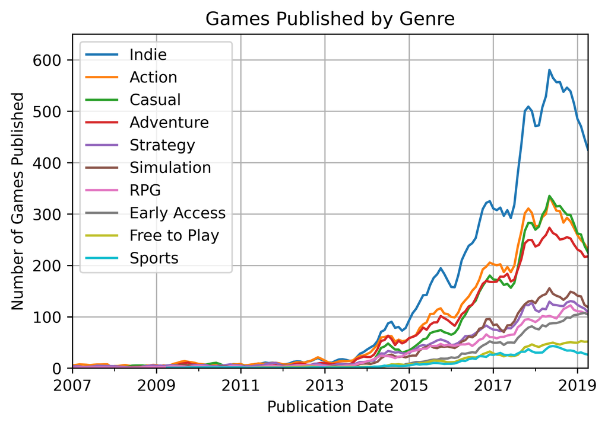

```python
plt.figure(dpi=600)

for i in range(len(top_genres)):
  df = genre_games[i]

  # no games pre-Steam
  df = df[(df['month'] >= '2005-01') & (df['month'] < '2019-05')]
  data = df.groupby(['month'])['appid'].count().to_frame()

  # moving average for smoothness
  data['MA'] = data.rolling(window=4).mean()

  ax = data['MA'].plot()
  plt.title('Games Published by Genre')
  plt.xlabel('Publication Date')
  plt.ylabel('Number of Games Published')
  plt.ylim(0, 650)
  plt.xlim('2007-01', '2019-04')
  plt.grid()
  plt.legend(top_genres)

plt.show()
```

The clear outlier here is the "Indie" genre, which says more about how the game is made than the game's actual content. All of the top genres have been ballooning massively since approximately 2014. They all experience troughs at around the same time, meaning those dips are less indicative of a genre-specific shortcoming and more related to the industry as a whole.

However, this only tells part of the story.

## **3b. Consumption**

Just because games are being made and published does not mean they're being bought and played. With thousands of games being published each year and only a few making headlines, the real story comes from what gamers are playing. For this, we'll take a look at user statistics. One of the most important numbers in any industry is revenue. For this, we can take the `total_ratings` as a population statistic and the `price` as a dollar amount and make a business-minded graph. As mentioned earlier, `total_ratings` is *not* the number of users who purchased a game, but the number who reviewed it. We are considering this statistic to be a percent of the total owner population, but as this can vary game to game, it is not entirely accurate.

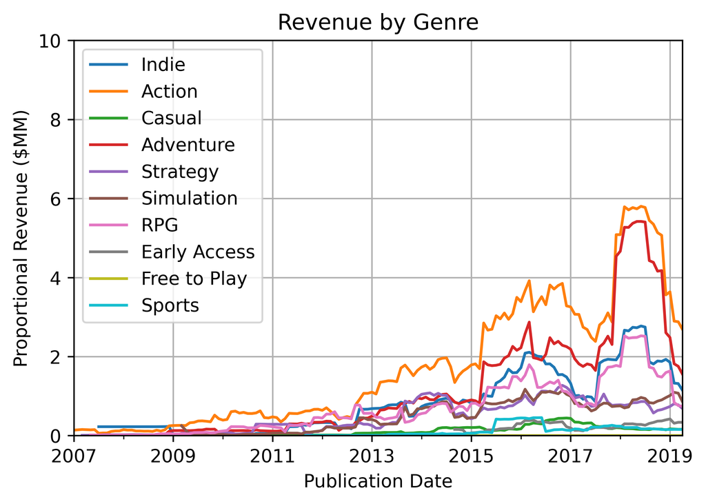

```python
plt.figure(dpi=600)

for i in range(len(top_genres)):
  df = genre_games[i]

  # no games pre-Steam
  df = df[(df['month'] >= '2003-01') & (df['month'] < '2019-05')]
  df['revenue'] = df['price'] * df['total_ratings']
  data = df.groupby(['month'])['revenue'].sum().to_frame()

  # moving average for smoothness
  data['MA'] = data.rolling(window=12).mean() / 1000000

  ax = data['MA'].plot()
  plt.title('Revenue by Genre')
  plt.xlabel('Publication Date')
  plt.ylabel('Proportional Revenue ($MM)')
  plt.ylim(0, 10)
  plt.xlim('2007-01', '2019-04')
  plt.grid()
  plt.legend(top_genres, loc='upper left')

plt.show()
```

This graph tells an entirely different story from the previous one. Indie games, while being the most prolific genre in terms of game publication, generate much less revenue than action and adventure titles. Casual games, the third most popular genre, generate the least of the top five, with very little growth overall. Casual games appear not to have many players, despite being a popular genre for creators.

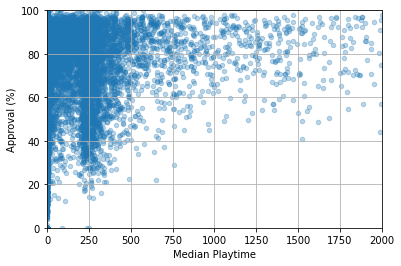

```python
# metric by which we rate a game as "good"
games['percent_approval'] = games['positive_ratings'] / games['total_ratings'] * 100
ax = games.plot.scatter(x='median_playtime', y='percent_approval', alpha=0.3)
plt.xlim(0, 2000)
plt.ylim(0, 100)
plt.grid()
plt.xlabel('Median Playtime')
plt.ylabel('Approval (%)')
```